# PA1_template

Javier

31 de octubre de 2016

# Reproducible Research: Peer Assigment 1

## Loading and Processing Data

If you already download the zip file, please extract the files in your working directory and keep the names of file as “activity.csv”. If you haven´t, the code will download the zip file and extract the files for you.

```r
WD <- getwd()
dest_file1 <- paste(WD, "/activity.csv")
dest_file1 <- gsub(" /", "/", dest_file1)

if (!file.exists(dest_file1, showWarnings = FALSE)){
  URL <- "https://d396qusza40orc.cloudfront.net/repdata%2Fdata%2Factivity.zip"
  temp <- tempfile()
  download.file(URL, temp)
  unzip(temp, c("activity.csv"), exdir = WD )
  ActivityData <- read.csv("activity.csv")
  unlink(temp)
}else{
  ActivityData <- read.csv("activity.csv")
}
```

First we calculate the total number of steps taken per day:

```r
library(ggplot2)
TotalSteps <- tapply(ActivityData$steps, ActivityData$date, FUN = sum, na.rm = TRUE)
```

Then, we make a histogram of the total number of steps taken each day:

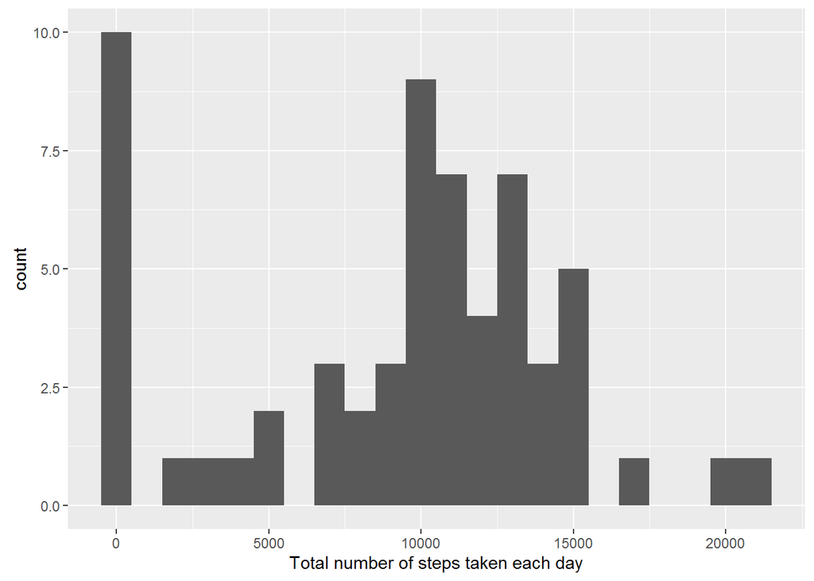

```r
qplot(TotalSteps, binwidth = 1000, xlab = "Total number of steps taken each day")
```

```r
Mean1 <- mean(TotalSteps, na.rm = TRUE)
Median1 <- median(TotalSteps, na.rm = TRUE)
```

## What is the average daily activity pattern?

First, we make a time series plot (i.e. type = “l”) of the 5-minute interval (x-axis) and the average number of steps taken, averaged across all days (y-axis):

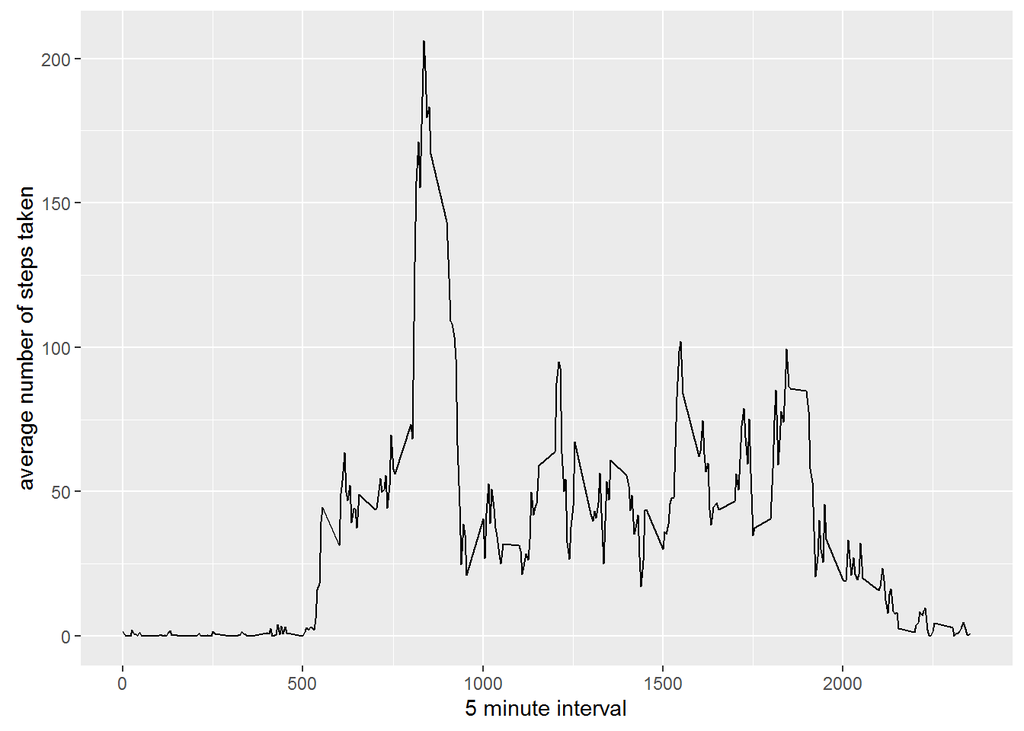

```r
Averages <- aggregate(x=list(steps = ActivityData$steps), by=list(interval = ActivityData$interval), FUN = mean, na.rm = TRUE)
ggplot(data = Averages, aes(x=interval, y=steps)) + geom_line() + xlab("5 minute interval") + ylab("average number of steps taken")
```

Finally, we calculate the maximum number of steps on average across all the days in the dataset in a 5-minutes interval:

```r
Averages[which.max(Averages$steps),]
```

```
##     interval    steps
## 104      835 206.1698
```

## Imputing missing values

we calculate and report the total number of missing values in the dataset (i.e. the total number of rows with NAs) as follows:

```r
Missing <- is.na(ActivityData$steps)
table(Missing)
```

```
## Missing
## FALSE  TRUE
## 15264  2304
```

Then, all the missing values are filled in with mean value for that 5-minute interval.

```r
FillValue <- function(steps, interval) {
  Filled <- NA
  if (!is.na(steps))
    Filled <- c(steps)
  else
    Filled <- (Averages[Averages$interval==interval, "steps"])
  return(Filled)
}
FilledData <- ActivityData
FilledData$steps <- mapply(FillValue, FilledData$steps, FilledData$interval)
```

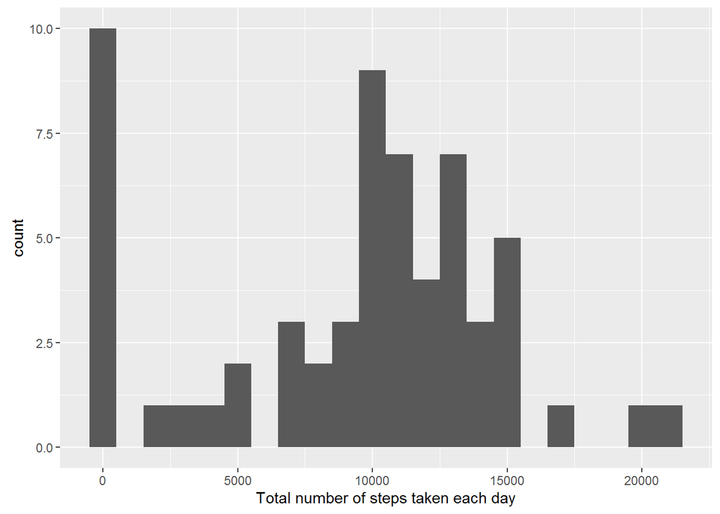

```r
library(ggplot2)
TotalSteps <- tapply(ActivityData$steps, ActivityData$date, FUN = sum, na.rm = TRUE)
qplot(TotalSteps, binwidth = 1000, xlab = "Total number of steps taken each day")
```

```r
Mean2 <- mean(TotalSteps, na.rm = TRUE)
Median2 <- median(TotalSteps, na.rm = TRUE)
```

## Are there differences in activity patterns between weekdays and weekends?

First, we create a new factor variable in the dataset with two levels - “weekday” and “weekend” indicating whether a given date is a weekday or weekend day.

```r
WeekdayOrWeekend <- function(Date) {
  Day <- weekdays(Date)
  if (Day %in% c("lunes", "martes", "miércoles", "jueves", "viernes"))
    return("Weekday")
  else if (Day %in% c("sábado", "domingo"))
    return("Weekend")
  else
    stop("Invalid date")
}
FilledData$date <- as.Date(FilledData$date)
FilledData$day <- sapply(FilledData$date, FUN = WeekdayOrWeekend)
```

Finally, we make a panel plot containing a time series plot (i.e. type = “l”) of the 5-minute interval (x-axis) and the average number of steps taken, averaged across all weekday days or weekend days (y-axis).

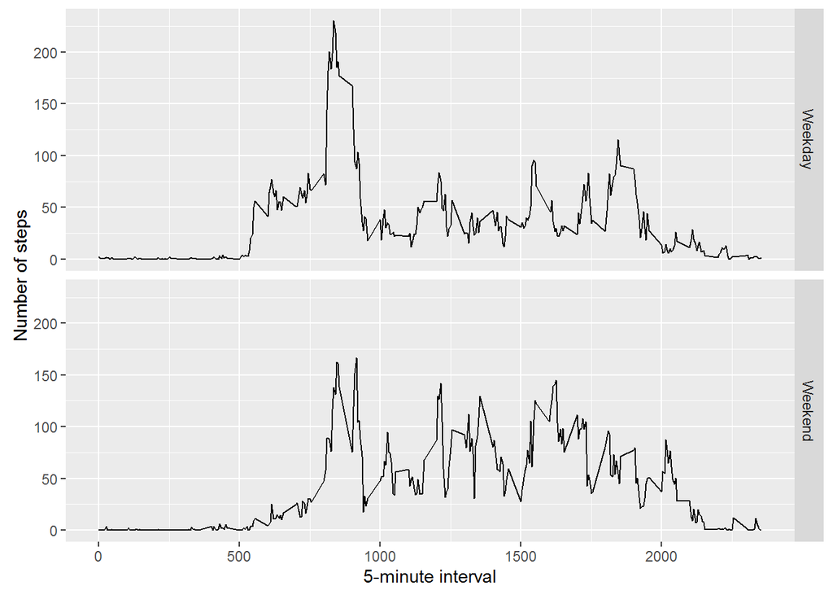

```r
Averages <- aggregate(steps ~ interval + day, data = FilledData, mean)
ggplot(Averages, aes(interval, steps)) + geom_line() + facet_grid(day ~ .) +
 xlab("5-minute interval") + ylab("Number of steps")
```